# Poisson Regression

Pablo Arés Gastesi

Sep 2025

```r
require(ggplot2)
require(sandwich)
require(msm)
```

# Poisson distribution and regression

What technique shall we use to model the counting of variables? Recall the Poisson probability distribution: it is a discrete distribution, with a single parameter $\lambda$, given by the following expression:
$$P(X = k) =
\frac{e^{-\lambda}\lambda^k}{k!}.$$
The parameter $\lambda$ is understood as a rate: number of accidents per day, number of people admitted into emergency room per hour, etc. It can be scaled, in the sense that if $\lambda$ corresponds to, say, defects in a meter of a wire, in two meters we have $2\lambda$, and in half a meter we will have $0.5\lambda$. A characteristic of the Poisson distribution is that the mean and the variance are both equal to $\lambda$.

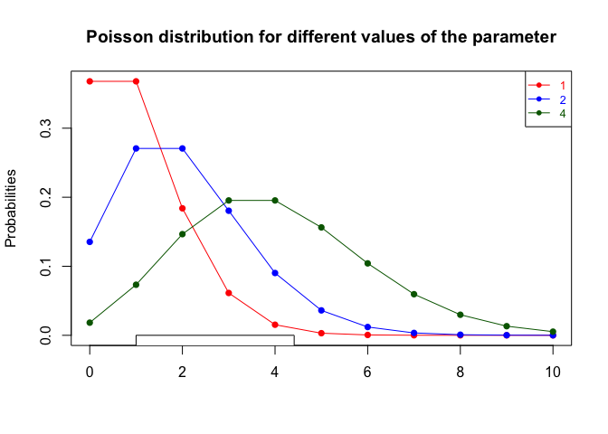

```r
x <- 0:10
y <- dpois(x, lambda = 1)
z <- dpois(x, lambda = 2)
w <- dpois(x, lambda = 4)
plot(x, y, col="red", pch=16, type="o", xlab = "", ylab = "Probabilities",
     main = "Poisson distribution for different values of the parameter")
points(x, z, col="blue", pch=16, type="o")
points(x, w, col="darkgreen", pch=16, type = "o")
legend(x = 0, y = NULL, "Poisson distribution")
legend("topright",legend=c(1, 2, 4), col=c("red", "blue", "darkgreen"),
       text.col = c("red", "blue", "darkgreen"), ncol=1, lty=1, pch=16, cex=0.8)
```

Due to the scalability property of this distribution, it is good to model count variables: how many times certain events take place. “The Poisson regression assume that the response variable has a Poisson distribution, and assumes the log of its expected value can be modeled by a linear combination of unknowns parameters” ([Wikipedia](https://en.wikipedia.org/wiki/Poisson_regression)). Mathematically
$$\ln(E[Y|x]) = \alpha +
\beta\,x$$
Thus the model gives a linear expression for the log of the conditional expected values. Some of the problems in the use of Poisson regressino occur when, for example, the observed variance is greater than the mean (overdispersion) or excesss zeroes.

# Example 1

Let us work an example taken from reference 1. [this link](https://stats.oarc.ucla.edu/r/dae/poisson-regression). The data has the number of awards earned by students in high school, along with their scores in the final math examination, and the program in which the students are enrolled: “General”, “Academic” and “Vocational”, encoded by numbers 1, 2 and 3 respectively. We start by reading the data and looking at the names of the variables.

```r
poisson.sim <- read.csv("poisson-simulated-1.csv")
colnames(poisson.sim)
```

```
## [1] "id"         "num_awards" "prog"       "math"
```

Let us convert variable **program** to a factor. And make barplots of the three categories.

```r
poisson.sim$prog <- factor(poisson.sim$prog, levels = 1:3,
                          labels = c("General", "Academic", "Vocational"))
```

And now let us look at the barplots of the awards by categories.

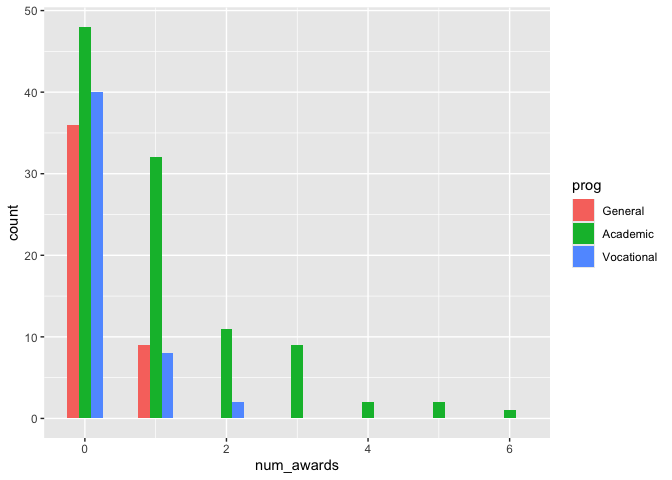

```r
ggplot(data = poisson.sim, aes(x = num_awards, fill = prog)) +
       geom_histogram(binwidth = 0.5, position="dodge")
```

```r
summary(poisson.sim[,-1])
```

```
##    num_awards           prog          math
##  Min.   :0.00   General   : 45   Min.   :33.00
##  1st Qu.:0.00   Academic  :105   1st Qu.:45.00
##  Median :0.00   Vocational: 50   Median :52.00
##  Mean   :0.63                    Mean   :52.65
##  3rd Qu.:1.00                    3rd Qu.:59.00
##  Max.   :6.00                    Max.   :75.00
```

Here we have the means and variance by the enrollment programs.

```r
medias <- as.numeric(by(poisson.sim$num_awards, poisson.sim$prog, mean))
variance <- round(as.numeric(by(poisson.sim$num_awards, poisson.sim$prog, var)), 2)
```

```
## [1] "Medias"
```

```
## [1] "General: 0.2 Academic: 1 Vocational: 0.24"
```

```
## [1] "Variance"
```

```
## [1] "General: 0.16  Academic: 1.63 Vocational 0.27"
```

And now let us make the Poisson regression, using the **glm** instruction, with **family = “poisson”**

```r
summary(m1 <- glm(num_awards ~ prog + math, family="poisson", data=poisson.sim))
```

```
##
## Call:
## glm(formula = num_awards ~ prog + math, family = "poisson", data = poisson.sim)
##
## Coefficients:
##                Estimate Std. Error z value Pr(>|z|)
## (Intercept)    -5.24712    0.65845  -7.969 1.60e-15 ***
## progAcademic    1.08386    0.35825   3.025  0.00248 **
## progVocational  0.36981    0.44107   0.838  0.40179
## math            0.07015    0.01060   6.619 3.63e-11 ***
## ---
## Signif. codes:  0 '***' 0.001 '**' 0.01 '*' 0.05 '.' 0.1 ' ' 1
##
## (Dispersion parameter for poisson family taken to be 1)
##
##     Null deviance: 287.67  on 199  degrees of freedom
## Residual deviance: 189.45  on 196  degrees of freedom
## AIC: 373.5
##
## Number of Fisher Scoring iterations: 6
```

The coefficient for **math** is 0.07, which means that an increase of one unit in maths increases the log of the expected count increases by 0.07. And hence the count is multiplied by $e^{0.07} = 1.07$. The indicator variable **progAcademic** compares between prog = “Academic” and prog = “General”

The R package **sandwich** can be used to estimate the parameters by what is known as robust standard errors. Here you have the code along with the p-values and the 95% confidence interval.

```r
cov.m1 <- vcovHC(m1, type="HC0")
std.err <- sqrt(diag(cov.m1))
r.est <- cbind(Estimate= coef(m1), "Robust SE" = std.err,
"Pr(>|z|)" = 2 * pnorm(abs(coef(m1)/std.err), lower.tail=FALSE),
LL = coef(m1) - 1.96 * std.err,
UL = coef(m1) + 1.96 * std.err)
r.est
```

```
##                  Estimate  Robust SE     Pr(>|z|)          LL          UL
## (Intercept)    -5.2471244 0.64599839 4.566630e-16 -6.51328124 -3.98096756
## progAcademic    1.0838591 0.32104816 7.354745e-04  0.45460476  1.71311353
## progVocational  0.3698092 0.40041731 3.557157e-01 -0.41500870  1.15462716
## math            0.0701524 0.01043516 1.783975e-11  0.04969947  0.09060532
```

We can also graph the predicted number of events with the commands below. The graph indicates that the most awards are predicted for those in the academic program (prog = 2), especially if the student has a high math score.

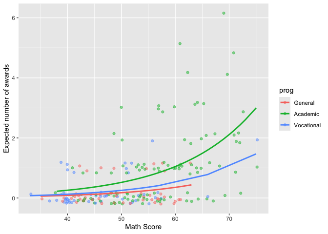

```r
poisson.sim$phat <- predict(m1, type="response")
ggplot(poisson.sim, aes(x = math, y = phat, colour = prog)) +
  geom_point(aes(y = num_awards), alpha=.5, position=position_jitter(h=.2)) +
  geom_line(linewidth = 1) +
  labs(x = "Math Score", y = "Expected number of awards")
```

# Example 2

This time we consider the example at reference 2.

```r
poisson.sim.2 <- read.csv("poisson-simulated-2.csv")
summary(m2 <- glm(y ~ x, family="poisson", data=poisson.sim.2))
```

```
##
## Call:
## glm(formula = y ~ x, family = "poisson", data = poisson.sim.2)
##
## Coefficients:
##             Estimate Std. Error z value Pr(>|z|)
## (Intercept)  0.30787    0.28943   1.064    0.287
## x            0.07636    0.01730   4.413 1.02e-05 ***
## ---
## Signif. codes:  0 '***' 0.001 '**' 0.01 '*' 0.05 '.' 0.1 ' ' 1
##
## (Dispersion parameter for poisson family taken to be 1)
##
##     Null deviance: 48.310  on 29  degrees of freedom
## Residual deviance: 27.842  on 28  degrees of freedom
## AIC: 124.5
##
## Number of Fisher Scoring iterations: 4
```

The **pseudo** ${\boldsymbol R^2}$ is defined by
$$R^2 =
\frac{l(\hat{\beta_0})-l(\hat{\beta})}{l(\hat{\beta_0})} =
1 - \frac{-2l(\hat{\beta})}{-2l(\hat{\beta_0})}$$
where $l(\hat{\beta_0})$ is the log likelihood of the model when only the intercept is included. The pseudo $R^2$ goes from 0 to 1 with 1 being a perfect fit. It can also be computed as $1-\frac{\text{residual deviance}}{\text{null/total deviance}}$. In this case we have it is equal to

```r
1 - m2$deviance / m2$null.deviance
```

```
## [1] 0.423676
```

# In-class exercise

1. Install and load the package *faraway*.
2. Consider the data set *esdcomp* from that package.
3. Do a few plots to study the data.
4. Is it good for a Poisson regression?
5. Even it is not good, do a Poisson regression for computing the number of complaints from the number of visits.
6. How good is your model?
7. Read about overdispersion in Poisson regression, how to detect it and how to fix the problem. Write a summary of what you find.

# References

1. [UCLA](https://stats.oarc.ucla.edu/r/dae/poisson-regression).
2. [Penn State University](https://online.stat.psu.edu/stat462/node/209)

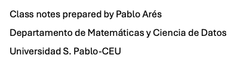